# Risk Factor Analysis

## Outcome Variable

**Outcome Variable:** whz

## Predictor Variables

**Intervention Variable:** single

**Adjustment Set:**

- arm
- W_mage
- W_fage
- meducyrs
- feducyrs
- W_mhtcm
- W_mwtkg
- W_mbmi
- W_gagebrth
- W_birthwt
- W_birthlen
- vagbrth
- parity
- delta_W_mage
- delta_W_fage
- delta_meducyrs
- delta_feducyrs
- delta_W_mhtcm
- delta_W_mwtkg
- delta_W_mbmi
- delta_W_gagebrth
- delta_W_birthwt
- delta_W_birthlen
- delta_vagbrth
- delta_parity

## Stratifying Variables

The analysis was stratified on these variable(s):

- agecat
- studyid
- country

## Data Summary

| agecat | studyid | country | single | n_cell | n |
| --- | --- | --- | --- | --- | --- |
| 6 months | ki0047075b-MAL-ED | BANGLADESH | 0 | 241 | 241 |
| 6 months | ki0047075b-MAL-ED | BANGLADESH | 1 | 0 | 241 |
| 6 months | ki0047075b-MAL-ED | BRAZIL | 0 | 179 | 209 |
| 6 months | ki0047075b-MAL-ED | BRAZIL | 1 | 30 | 209 |
| 6 months | ki0047075b-MAL-ED | INDIA | 0 | 234 | 234 |
| 6 months | ki0047075b-MAL-ED | INDIA | 1 | 0 | 234 |
| 6 months | ki0047075b-MAL-ED | NEPAL | 0 | 236 | 236 |
| 6 months | ki0047075b-MAL-ED | NEPAL | 1 | 0 | 236 |
| 6 months | ki0047075b-MAL-ED | PERU | 0 | 240 | 273 |
| 6 months | ki0047075b-MAL-ED | PERU | 1 | 33 | 273 |
| 6 months | ki0047075b-MAL-ED | SOUTH AFRICA | 0 | 140 | 254 |
| 6 months | ki0047075b-MAL-ED | SOUTH AFRICA | 1 | 114 | 254 |
| 6 months | ki0047075b-MAL-ED | TANZANIA, UNITED REPUBLIC OF | 0 | 239 | 247 |
| 6 months | ki0047075b-MAL-ED | TANZANIA, UNITED REPUBLIC OF | 1 | 8 | 247 |
| 6 months | ki1066203-TanzaniaChild2 | TANZANIA, UNITED REPUBLIC OF | 0 | 1834 | 2012 |
| 6 months | ki1066203-TanzaniaChild2 | TANZANIA, UNITED REPUBLIC OF | 1 | 178 | 2012 |
| 6 months | ki1112895-Guatemala BSC | GUATEMALA | 0 | 248 | 277 |
| 6 months | ki1112895-Guatemala BSC | GUATEMALA | 1 | 29 | 277 |
| 6 months | ki1119695-PROBIT | BELARUS | 0 | 15114 | 15757 |
| 6 months | ki1119695-PROBIT | BELARUS | 1 | 643 | 15757 |
| 6 months | ki1126311-ZVITAMBO | ZIMBABWE | 0 | 7746 | 8234 |
| 6 months | ki1126311-ZVITAMBO | ZIMBABWE | 1 | 488 | 8234 |
| 6 months | ki1135781-COHORTS | GUATEMALA | 0 | 827 | 894 |
| 6 months | ki1135781-COHORTS | GUATEMALA | 1 | 67 | 894 |
| 6 months | ki1135781-COHORTS | INDIA | 0 | 4955 | 4964 |
| 6 months | ki1135781-COHORTS | INDIA | 1 | 9 | 4964 |
| 6 months | ki1135781-COHORTS | PHILIPPINES | 0 | 2606 | 2674 |
| 6 months | ki1135781-COHORTS | PHILIPPINES | 1 | 68 | 2674 |
| 24 months | ki0047075b-MAL-ED | BANGLADESH | 0 | 212 | 212 |
| 24 months | ki0047075b-MAL-ED | BANGLADESH | 1 | 0 | 212 |
| 24 months | ki0047075b-MAL-ED | BRAZIL | 0 | 148 | 169 |
| 24 months | ki0047075b-MAL-ED | BRAZIL | 1 | 21 | 169 |
| 24 months | ki0047075b-MAL-ED | INDIA | 0 | 225 | 225 |
| 24 months | ki0047075b-MAL-ED | INDIA | 1 | 0 | 225 |
| 24 months | ki0047075b-MAL-ED | NEPAL | 0 | 228 | 228 |
| 24 months | ki0047075b-MAL-ED | NEPAL | 1 | 0 | 228 |
| 24 months | ki0047075b-MAL-ED | PERU | 0 | 176 | 201 |
| 24 months | ki0047075b-MAL-ED | PERU | 1 | 25 | 201 |
| 24 months | ki0047075b-MAL-ED | SOUTH AFRICA | 0 | 131 | 238 |
| 24 months | ki0047075b-MAL-ED | SOUTH AFRICA | 1 | 107 | 238 |
| 24 months | ki0047075b-MAL-ED | TANZANIA, UNITED REPUBLIC OF | 0 | 208 | 214 |
| 24 months | ki0047075b-MAL-ED | TANZANIA, UNITED REPUBLIC OF | 1 | 6 | 214 |
| 24 months | ki1066203-TanzaniaChild2 | TANZANIA, UNITED REPUBLIC OF | 0 | 6 | 6 |
| 24 months | ki1066203-TanzaniaChild2 | TANZANIA, UNITED REPUBLIC OF | 1 | 0 | 6 |
| 24 months | ki1119695-PROBIT | BELARUS | 0 | 3829 | 3971 |
| 24 months | ki1119695-PROBIT | BELARUS | 1 | 142 | 3971 |
| 24 months | ki1126311-ZVITAMBO | ZIMBABWE | 0 | 379 | 422 |
| 24 months | ki1126311-ZVITAMBO | ZIMBABWE | 1 | 43 | 422 |
| 24 months | ki1135781-COHORTS | GUATEMALA | 0 | 932 | 1021 |
| 24 months | ki1135781-COHORTS | GUATEMALA | 1 | 89 | 1021 |
| 24 months | ki1135781-COHORTS | INDIA | 0 | 3717 | 3726 |
| 24 months | ki1135781-COHORTS | INDIA | 1 | 9 | 3726 |
| 24 months | ki1135781-COHORTS | PHILIPPINES | 0 | 2361 | 2420 |
| 24 months | ki1135781-COHORTS | PHILIPPINES | 1 | 59 | 2420 |

The following strata were considered:

- agecat: 24 months, studyid: ki0047075b-MAL-ED, country: BANGLADESH
- agecat: 24 months, studyid: ki0047075b-MAL-ED, country: BRAZIL
- agecat: 24 months, studyid: ki0047075b-MAL-ED, country: INDIA
- agecat: 24 months, studyid: ki0047075b-MAL-ED, country: NEPAL
- agecat: 24 months, studyid: ki0047075b-MAL-ED, country: PERU
- agecat: 24 months, studyid: ki0047075b-MAL-ED, country: SOUTH AFRICA
- agecat: 24 months, studyid: ki0047075b-MAL-ED, country: TANZANIA, UNITED REPUBLIC OF
- agecat: 24 months, studyid: ki1066203-TanzaniaChild2, country: TANZANIA, UNITED REPUBLIC OF
- agecat: 24 months, studyid: ki1119695-PROBIT, country: BELARUS
- agecat: 24 months, studyid: ki1126311-ZVITAMBO, country: ZIMBABWE
- agecat: 24 months, studyid: ki1135781-COHORTS, country: GUATEMALA
- agecat: 24 months, studyid: ki1135781-COHORTS, country: INDIA
- agecat: 24 months, studyid: ki1135781-COHORTS, country: PHILIPPINES
- agecat: 6 months, studyid: ki0047075b-MAL-ED, country: BANGLADESH
- agecat: 6 months, studyid: ki0047075b-MAL-ED, country: BRAZIL
- agecat: 6 months, studyid: ki0047075b-MAL-ED, country: INDIA
- agecat: 6 months, studyid: ki0047075b-MAL-ED, country: NEPAL
- agecat: 6 months, studyid: ki0047075b-MAL-ED, country: PERU
- agecat: 6 months, studyid: ki0047075b-MAL-ED, country: SOUTH AFRICA
- agecat: 6 months, studyid: ki0047075b-MAL-ED, country: TANZANIA, UNITED REPUBLIC OF
- agecat: 6 months, studyid: ki1066203-TanzaniaChild2, country: TANZANIA, UNITED REPUBLIC OF
- agecat: 6 months, studyid: ki1112895-Guatemala BSC, country: GUATEMALA
- agecat: 6 months, studyid: ki1119695-PROBIT, country: BELARUS
- agecat: 6 months, studyid: ki1126311-ZVITAMBO, country: ZIMBABWE
- agecat: 6 months, studyid: ki1135781-COHORTS, country: GUATEMALA
- agecat: 6 months, studyid: ki1135781-COHORTS, country: INDIA
- agecat: 6 months, studyid: ki1135781-COHORTS, country: PHILIPPINES

### Dropped Strata

- agecat: 6 months, studyid: ki0047075b-MAL-ED, country: BANGLADESH
- agecat: 6 months, studyid: ki0047075b-MAL-ED, country: INDIA
- agecat: 6 months, studyid: ki0047075b-MAL-ED, country: NEPAL
- agecat: 24 months, studyid: ki0047075b-MAL-ED, country: BANGLADESH
- agecat: 24 months, studyid: ki0047075b-MAL-ED, country: INDIA
- agecat: 24 months, studyid: ki0047075b-MAL-ED, country: NEPAL
- agecat: 24 months, studyid: ki1066203-TanzaniaChild2, country: TANZANIA, UNITED REPUBLIC OF

## Methods Detail

We’re interested in the causal parameters $E[Y_a]$ for all values of $a \in \mathcal{A}$. These parameters represent the mean outcome if, possibly contrary to fact, we intervened to set all units to have $A=a$. Under the randomization and positivity assumptions, these are identified by the statistical parameters $\psi_a=E_W[E_{Y|A,W}(Y|A=a,W)]$. In addition, we’re interested in the mean of $Y$, $E[Y]$ under no intervention (the observed mean). We will estimate these parameters by using SuperLearner to fit the relevant likelihood factors – $E_{Y|A,W}(Y|A=a,W)$ and $p(A=a|W)$, and then updating our likelihood fit using a joint TMLE.

For unadjusted analyses ($W=\{\}$), initial likelihoods were estimated using Lrnr_glm to estimate the simple $E(Y|A)$ and Lrnr_mean to estimate $p(A)$. For adjusted analyses, a small library containing Lrnr_glmnet, Lrnr_xgboost, and Lrnr_mean was used.

Having estimated these parameters, we will then use the delta method to estimate relative risks and attributable risks relative to a prespecified baseline level of $A$.

# Results Detail

## Results Plots

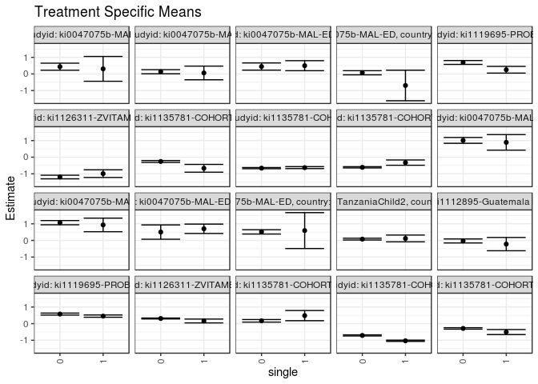

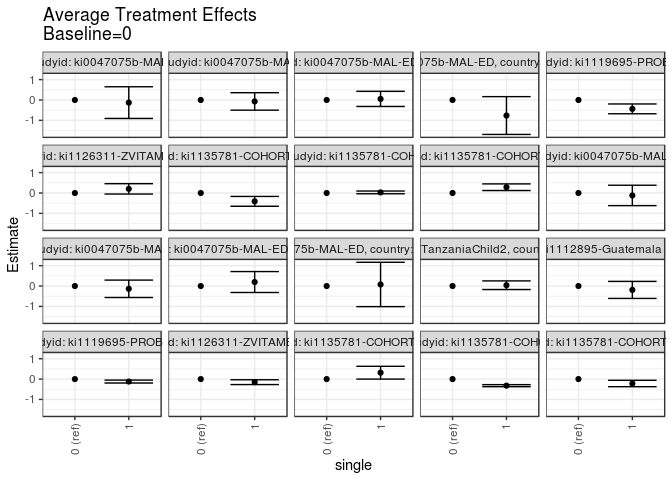

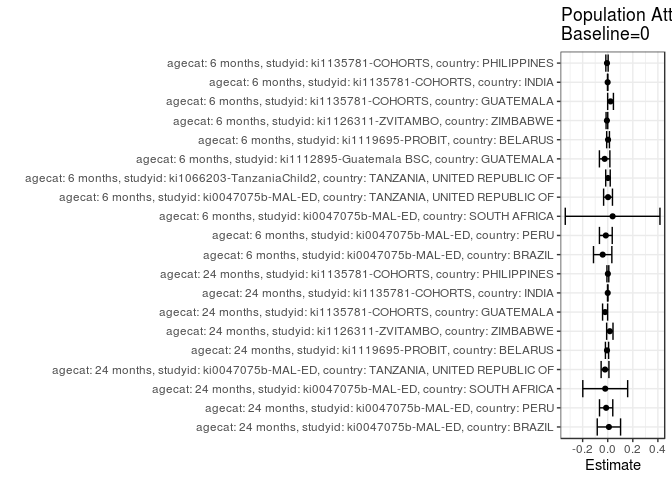

## Results Table

### Parameter: TSM

| agecat | studyid | country | intervention_level | baseline_level | estimate | ci_lower | ci_upper |
| --- | --- | --- | --- | --- | --- | --- | --- |
| 6 months | ki0047075b-MAL-ED | BRAZIL | 0 | NA | 1.0119521 | 0.8359674 | 1.1879368 |
| 6 months | ki0047075b-MAL-ED | BRAZIL | 1 | NA | 0.8925005 | 0.4229832 | 1.3620177 |
| 6 months | ki0047075b-MAL-ED | PERU | 0 | NA | 1.0694292 | 0.9430338 | 1.1958246 |
| 6 months | ki0047075b-MAL-ED | PERU | 1 | NA | 0.9335728 | 0.5253511 | 1.3417945 |
| 6 months | ki0047075b-MAL-ED | SOUTH AFRICA | 0 | NA | 0.5030504 | 0.0717537 | 0.9343471 |
| 6 months | ki0047075b-MAL-ED | SOUTH AFRICA | 1 | NA | 0.7005894 | 0.4184197 | 0.9827592 |
| 6 months | ki0047075b-MAL-ED | TANZANIA, UNITED REPUBLIC OF | 0 | NA | 0.5145258 | 0.3853273 | 0.6437243 |
| 6 months | ki0047075b-MAL-ED | TANZANIA, UNITED REPUBLIC OF | 1 | NA | 0.5925000 | -0.4882365 | 1.6732365 |
| 6 months | ki1066203-TanzaniaChild2 | TANZANIA, UNITED REPUBLIC OF | 0 | NA | 0.0778640 | 0.0231385 | 0.1325895 |
| 6 months | ki1066203-TanzaniaChild2 | TANZANIA, UNITED REPUBLIC OF | 1 | NA | 0.1178678 | -0.0864685 | 0.3222040 |
| 6 months | ki1112895-Guatemala BSC | GUATEMALA | 0 | NA | -0.0323262 | -0.1536680 | 0.0890155 |
| 6 months | ki1112895-Guatemala BSC | GUATEMALA | 1 | NA | -0.2226754 | -0.6229365 | 0.1775857 |
| 6 months | ki1119695-PROBIT | BELARUS | 0 | NA | 0.5762740 | 0.5158310 | 0.6367169 |
| 6 months | ki1119695-PROBIT | BELARUS | 1 | NA | 0.4544414 | 0.3855741 | 0.5233087 |
| 6 months | ki1126311-ZVITAMBO | ZIMBABWE | 0 | NA | 0.3114342 | 0.2845181 | 0.3383504 |
| 6 months | ki1126311-ZVITAMBO | ZIMBABWE | 1 | NA | 0.1603302 | 0.0448152 | 0.2758451 |
| 6 months | ki1135781-COHORTS | GUATEMALA | 0 | NA | 0.1695062 | 0.0927191 | 0.2462932 |
| 6 months | ki1135781-COHORTS | GUATEMALA | 1 | NA | 0.4832995 | 0.1776749 | 0.7889241 |
| 6 months | ki1135781-COHORTS | INDIA | 0 | NA | -0.7098951 | -0.7430287 | -0.6767615 |
| 6 months | ki1135781-COHORTS | INDIA | 1 | NA | -1.0322222 | -1.0700926 | -0.9943519 |
| 6 months | ki1135781-COHORTS | PHILIPPINES | 0 | NA | -0.2878918 | -0.3308336 | -0.2449499 |
| 6 months | ki1135781-COHORTS | PHILIPPINES | 1 | NA | -0.5047667 | -0.6570783 | -0.3524552 |
| 24 months | ki0047075b-MAL-ED | BRAZIL | 0 | NA | 0.4371764 | 0.2254295 | 0.6489232 |
| 24 months | ki0047075b-MAL-ED | BRAZIL | 1 | NA | 0.3073067 | -0.4392963 | 1.0539098 |
| 24 months | ki0047075b-MAL-ED | PERU | 0 | NA | 0.1325235 | 0.0086811 | 0.2563659 |
| 24 months | ki0047075b-MAL-ED | PERU | 1 | NA | 0.0606342 | -0.3514715 | 0.4727398 |
| 24 months | ki0047075b-MAL-ED | SOUTH AFRICA | 0 | NA | 0.4465868 | 0.2296198 | 0.6635539 |
| 24 months | ki0047075b-MAL-ED | SOUTH AFRICA | 1 | NA | 0.4984027 | 0.1960968 | 0.8007086 |
| 24 months | ki0047075b-MAL-ED | TANZANIA, UNITED REPUBLIC OF | 0 | NA | 0.0715385 | -0.0529948 | 0.1960717 |
| 24 months | ki0047075b-MAL-ED | TANZANIA, UNITED REPUBLIC OF | 1 | NA | -0.6933333 | -1.6135001 | 0.2268334 |
| 24 months | ki1119695-PROBIT | BELARUS | 0 | NA | 0.6919572 | 0.5760904 | 0.8078239 |
| 24 months | ki1119695-PROBIT | BELARUS | 1 | NA | 0.2545234 | 0.0514854 | 0.4575614 |
| 24 months | ki1126311-ZVITAMBO | ZIMBABWE | 0 | NA | -1.1948610 | -1.3029880 | -1.0867339 |
| 24 months | ki1126311-ZVITAMBO | ZIMBABWE | 1 | NA | -0.9903211 | -1.2208257 | -0.7598165 |
| 24 months | ki1135781-COHORTS | GUATEMALA | 0 | NA | -0.2587928 | -0.3159133 | -0.2016722 |
| 24 months | ki1135781-COHORTS | GUATEMALA | 1 | NA | -0.6683200 | -0.9032353 | -0.4334048 |
| 24 months | ki1135781-COHORTS | INDIA | 0 | NA | -0.6594835 | -0.6934635 | -0.6255034 |
| 24 months | ki1135781-COHORTS | INDIA | 1 | NA | -0.6300000 | -0.6887577 | -0.5712423 |
| 24 months | ki1135781-COHORTS | PHILIPPINES | 0 | NA | -0.6112385 | -0.6489387 | -0.5735382 |
| 24 months | ki1135781-COHORTS | PHILIPPINES | 1 | NA | -0.3271978 | -0.4858748 | -0.1685208 |

### Parameter: E(Y)

| agecat | studyid | country | intervention_level | baseline_level | estimate | ci_lower | ci_upper |
| --- | --- | --- | --- | --- | --- | --- | --- |
| 6 months | ki0047075b-MAL-ED | BRAZIL | NA | NA | 0.9717225 | 0.8073791 | 1.1360658 |
| 6 months | ki0047075b-MAL-ED | PERU | NA | NA | 1.0543956 | 0.9326967 | 1.1760945 |
| 6 months | ki0047075b-MAL-ED | SOUTH AFRICA | NA | NA | 0.5420735 | 0.3899459 | 0.6942011 |
| 6 months | ki0047075b-MAL-ED | TANZANIA, UNITED REPUBLIC OF | NA | NA | 0.5170513 | 0.3872178 | 0.6468847 |
| 6 months | ki1066203-TanzaniaChild2 | TANZANIA, UNITED REPUBLIC OF | NA | NA | 0.0797577 | 0.0268998 | 0.1326156 |
| 6 months | ki1112895-Guatemala BSC | GUATEMALA | NA | NA | -0.0568833 | -0.1722874 | 0.0585208 |
| 6 months | ki1119695-PROBIT | BELARUS | NA | NA | 0.5789633 | 0.5190130 | 0.6389137 |
| 6 months | ki1126311-ZVITAMBO | ZIMBABWE | NA | NA | 0.3050103 | 0.2788985 | 0.3311222 |
| 6 months | ki1135781-COHORTS | GUATEMALA | NA | NA | 0.1920134 | 0.1173734 | 0.2666534 |
| 6 months | ki1135781-COHORTS | INDIA | NA | NA | -0.7104795 | -0.7428008 | -0.6781581 |
| 6 months | ki1135781-COHORTS | PHILIPPINES | NA | NA | -0.2936948 | -0.3352840 | -0.2521057 |
| 24 months | ki0047075b-MAL-ED | BRAZIL | NA | NA | 0.4466272 | 0.2416144 | 0.6516401 |
| 24 months | ki0047075b-MAL-ED | PERU | NA | NA | 0.1199005 | -0.0000331 | 0.2398341 |
| 24 months | ki0047075b-MAL-ED | SOUTH AFRICA | NA | NA | 0.4267017 | 0.3074751 | 0.5459283 |
| 24 months | ki0047075b-MAL-ED | TANZANIA, UNITED REPUBLIC OF | NA | NA | 0.0500935 | -0.0748234 | 0.1750103 |
| 24 months | ki1119695-PROBIT | BELARUS | NA | NA | 0.6863435 | 0.5745700 | 0.7981170 |
| 24 months | ki1126311-ZVITAMBO | ZIMBABWE | NA | NA | -1.1781043 | -1.2781256 | -1.0780830 |
| 24 months | ki1135781-COHORTS | GUATEMALA | NA | NA | -0.2796964 | -0.3351582 | -0.2242346 |
| 24 months | ki1135781-COHORTS | INDIA | NA | NA | -0.6594122 | -0.6925753 | -0.6262491 |
| 24 months | ki1135781-COHORTS | PHILIPPINES | NA | NA | -0.6100579 | -0.6471813 | -0.5729344 |

### Parameter: ATE

| agecat | studyid | country | intervention_level | baseline_level | estimate | ci_lower | ci_upper |
| --- | --- | --- | --- | --- | --- | --- | --- |
| 6 months | ki0047075b-MAL-ED | BRAZIL | 0 | 0 | 0.0000000 | 0.0000000 | 0.0000000 |
| 6 months | ki0047075b-MAL-ED | BRAZIL | 1 | 0 | -0.1194516 | -0.6205512 | 0.3816480 |
| 6 months | ki0047075b-MAL-ED | PERU | 0 | 0 | 0.0000000 | 0.0000000 | 0.0000000 |
| 6 months | ki0047075b-MAL-ED | PERU | 1 | 0 | -0.1358564 | -0.5633673 | 0.2916545 |
| 6 months | ki0047075b-MAL-ED | SOUTH AFRICA | 0 | 0 | 0.0000000 | 0.0000000 | 0.0000000 |
| 6 months | ki0047075b-MAL-ED | SOUTH AFRICA | 1 | 0 | 0.1975390 | -0.3164993 | 0.7115774 |
| 6 months | ki0047075b-MAL-ED | TANZANIA, UNITED REPUBLIC OF | 0 | 0 | 0.0000000 | 0.0000000 | 0.0000000 |
| 6 months | ki0047075b-MAL-ED | TANZANIA, UNITED REPUBLIC OF | 1 | 0 | 0.0779742 | -1.0104576 | 1.1664060 |
| 6 months | ki1066203-TanzaniaChild2 | TANZANIA, UNITED REPUBLIC OF | 0 | 0 | 0.0000000 | 0.0000000 | 0.0000000 |
| 6 months | ki1066203-TanzaniaChild2 | TANZANIA, UNITED REPUBLIC OF | 1 | 0 | 0.0400038 | -0.1714909 | 0.2514985 |
| 6 months | ki1112895-Guatemala BSC | GUATEMALA | 0 | 0 | 0.0000000 | 0.0000000 | 0.0000000 |
| 6 months | ki1112895-Guatemala BSC | GUATEMALA | 1 | 0 | -0.1903492 | -0.6088920 | 0.2281936 |
| 6 months | ki1119695-PROBIT | BELARUS | 0 | 0 | 0.0000000 | 0.0000000 | 0.0000000 |
| 6 months | ki1119695-PROBIT | BELARUS | 1 | 0 | -0.1218325 | -0.1928937 | -0.0507714 |
| 6 months | ki1126311-ZVITAMBO | ZIMBABWE | 0 | 0 | 0.0000000 | 0.0000000 | 0.0000000 |
| 6 months | ki1126311-ZVITAMBO | ZIMBABWE | 1 | 0 | -0.1511041 | -0.2694679 | -0.0327403 |
| 6 months | ki1135781-COHORTS | GUATEMALA | 0 | 0 | 0.0000000 | 0.0000000 | 0.0000000 |
| 6 months | ki1135781-COHORTS | GUATEMALA | 1 | 0 | 0.3137933 | -0.0007833 | 0.6283699 |
| 6 months | ki1135781-COHORTS | INDIA | 0 | 0 | 0.0000000 | 0.0000000 | 0.0000000 |
| 6 months | ki1135781-COHORTS | INDIA | 1 | 0 | -0.3223272 | -0.3726461 | -0.2720082 |
| 6 months | ki1135781-COHORTS | PHILIPPINES | 0 | 0 | 0.0000000 | 0.0000000 | 0.0000000 |
| 6 months | ki1135781-COHORTS | PHILIPPINES | 1 | 0 | -0.2168750 | -0.3745043 | -0.0592456 |
| 24 months | ki0047075b-MAL-ED | BRAZIL | 0 | 0 | 0.0000000 | 0.0000000 | 0.0000000 |
| 24 months | ki0047075b-MAL-ED | BRAZIL | 1 | 0 | -0.1298696 | -0.9083739 | 0.6486346 |
| 24 months | ki0047075b-MAL-ED | PERU | 0 | 0 | 0.0000000 | 0.0000000 | 0.0000000 |
| 24 months | ki0047075b-MAL-ED | PERU | 1 | 0 | -0.0718893 | -0.5009773 | 0.3571986 |
| 24 months | ki0047075b-MAL-ED | SOUTH AFRICA | 0 | 0 | 0.0000000 | 0.0000000 | 0.0000000 |
| 24 months | ki0047075b-MAL-ED | SOUTH AFRICA | 1 | 0 | 0.0518159 | -0.3198521 | 0.4234839 |
| 24 months | ki0047075b-MAL-ED | TANZANIA, UNITED REPUBLIC OF | 0 | 0 | 0.0000000 | 0.0000000 | 0.0000000 |
| 24 months | ki0047075b-MAL-ED | TANZANIA, UNITED REPUBLIC OF | 1 | 0 | -0.7648718 | -1.6934273 | 0.1636837 |
| 24 months | ki1119695-PROBIT | BELARUS | 0 | 0 | 0.0000000 | 0.0000000 | 0.0000000 |
| 24 months | ki1119695-PROBIT | BELARUS | 1 | 0 | -0.4374338 | -0.6779323 | -0.1969352 |
| 24 months | ki1126311-ZVITAMBO | ZIMBABWE | 0 | 0 | 0.0000000 | 0.0000000 | 0.0000000 |
| 24 months | ki1126311-ZVITAMBO | ZIMBABWE | 1 | 0 | 0.2045399 | -0.0497676 | 0.4588474 |
| 24 months | ki1135781-COHORTS | GUATEMALA | 0 | 0 | 0.0000000 | 0.0000000 | 0.0000000 |
| 24 months | ki1135781-COHORTS | GUATEMALA | 1 | 0 | -0.4095273 | -0.6515370 | -0.1675176 |
| 24 months | ki1135781-COHORTS | INDIA | 0 | 0 | 0.0000000 | 0.0000000 | 0.0000000 |
| 24 months | ki1135781-COHORTS | INDIA | 1 | 0 | 0.0294835 | -0.0383923 | 0.0973592 |
| 24 months | ki1135781-COHORTS | PHILIPPINES | 0 | 0 | 0.0000000 | 0.0000000 | 0.0000000 |
| 24 months | ki1135781-COHORTS | PHILIPPINES | 1 | 0 | 0.2840407 | 0.1214008 | 0.4466806 |

### Parameter: PAR

| agecat | studyid | country | intervention_level | baseline_level | estimate | ci_lower | ci_upper |
| --- | --- | --- | --- | --- | --- | --- | --- |
| 6 months | ki0047075b-MAL-ED | BRAZIL | 0 | NA | -0.0402296 | -0.1134160 | 0.0329568 |
| 6 months | ki0047075b-MAL-ED | PERU | 0 | NA | -0.0150336 | -0.0659838 | 0.0359167 |
| 6 months | ki0047075b-MAL-ED | SOUTH AFRICA | 0 | NA | 0.0390231 | -0.3385526 | 0.4165988 |
| 6 months | ki0047075b-MAL-ED | TANZANIA, UNITED REPUBLIC OF | 0 | NA | 0.0025255 | -0.0327695 | 0.0378205 |
| 6 months | ki1066203-TanzaniaChild2 | TANZANIA, UNITED REPUBLIC OF | 0 | NA | 0.0018937 | -0.0160616 | 0.0198490 |
| 6 months | ki1112895-Guatemala BSC | GUATEMALA | 0 | NA | -0.0245571 | -0.0662858 | 0.0171717 |
| 6 months | ki1119695-PROBIT | BELARUS | 0 | NA | 0.0026893 | -0.0084116 | 0.0137903 |
| 6 months | ki1126311-ZVITAMBO | ZIMBABWE | 0 | NA | -0.0064239 | -0.0131108 | 0.0002630 |
| 6 months | ki1135781-COHORTS | GUATEMALA | 0 | NA | 0.0225072 | -0.0004753 | 0.0454898 |
| 6 months | ki1135781-COHORTS | INDIA | 0 | NA | -0.0005844 | -0.0018989 | 0.0007302 |
| 6 months | ki1135781-COHORTS | PHILIPPINES | 0 | NA | -0.0058031 | -0.0149892 | 0.0033831 |
| 24 months | ki0047075b-MAL-ED | BRAZIL | 0 | NA | 0.0094509 | -0.0836099 | 0.1025116 |
| 24 months | ki0047075b-MAL-ED | PERU | 0 | NA | -0.0126230 | -0.0655419 | 0.0402958 |
| 24 months | ki0047075b-MAL-ED | SOUTH AFRICA | 0 | NA | -0.0198852 | -0.1987749 | 0.1590045 |
| 24 months | ki0047075b-MAL-ED | TANZANIA, UNITED REPUBLIC OF | 0 | NA | -0.0214450 | -0.0525145 | 0.0096245 |
| 24 months | ki1119695-PROBIT | BELARUS | 0 | NA | -0.0056137 | -0.0183156 | 0.0070883 |
| 24 months | ki1126311-ZVITAMBO | ZIMBABWE | 0 | NA | 0.0167567 | -0.0085407 | 0.0420541 |
| 24 months | ki1135781-COHORTS | GUATEMALA | 0 | NA | -0.0209036 | -0.0410448 | -0.0007624 |
| 24 months | ki1135781-COHORTS | INDIA | 0 | NA | 0.0000712 | -0.0016263 | 0.0017687 |
| 24 months | ki1135781-COHORTS | PHILIPPINES | 0 | NA | 0.0011806 | -0.0063141 | 0.0086754 |